# Addendum Week 7

May 13, 2024

# Earthquake

After an earthquake has rattled our city, we have been asked to assess the damage. We are sent out to sample 1000 homes within bands of 1 km width within a 100 km radius of the epicenter. That is, within each of the 1 Km bands, we sample randomly 1000 homes and record the number that are damaged.

Given that the number of damaged property is a count variable and we sampled randomly we can assume that damage in one property is independent of damage at another property, and that damage is identically distributed: Hence, we choose to use a [Poisson](https://en.wikipedia.org/wiki/Poisson_distribution) model: $X_t \sim Poisson(\lambda_d),$ with $\lambda_d = 1000\exp(-\mu d)\psi$.

- $\mu$ describes the rate per kilometer at which the [intensity](https://www.usgs.gov/natural-hazards/earthquake-hazards/science/earthquake-magnitude-energy-release-and-shaking-intensity?qt-science_center_objects=0#qt-science_center_objects) of the earthquake diminishes as one moves away from the epicenter. (I made this all up - but a quick internet search revealed this is all a bit more complicated (surprise!). Geologists seem to rely on the “Intensity attenuation law” to obtain an integer scale that ranges from 1 to 10 to describe intensity as a function of distance (e.g., [Pasolini (2008)](https://core.ac.uk/download/pdf/11011494.pdf)). We pretend that we can quantify the intenisity attenuation by the change rate $\mu$).
- $\psi$ gives the proportion of homes that are *not* built up to code and may take damage
- $d$ takes distance to epicenter and ranges from 0, 99 km

Your priors for the paramters assume: $\mu \sim \Gamma(1,10)$ and $\psi \sim Beta(16,4)$

## Stan:

Stan model:

```
##
## rstan version 2.32.6 (Stan version 2.32.2)
```

[output not shown]

Stan model:

```stan
data {
  int< lower = 0 > N;     // Number of observations
  int< lower = 0 > x[N];  // Data
  vector<lower = 0>[N] d; // distance from epicenter
  real mu_shape;          // gamma shape prior
  real mu_rate;           // gamma rate prior
  real<lower = 0> psi_a;  // beta a shape
  real<lower = 0> psi_b;  // beta b shape
  int prior_only;         // if TRUE, likelihood is dropped
}
parameters {
  // Unknown parameters to be estimated
  real<lower=0> mu;
  real<lower=0, upper = 1> psi;
}
transformed parameters{
  // Not necessary to define lambda - but serves as illustration
  vector<lower = 0>[N] lambda;
  lambda = 1000*exp(-mu*d)*psi;
}
model {
  // Priors
  target += gamma_lpdf(mu | mu_shape, mu_rate);
  target += beta_lpdf( psi | psi_a, psi_b);
  // Likelihood
  if( prior_only == 0 ) {
    target  += poisson_lpmf(x | lambda );
  }
}
generated quantities {
  // x_rep are generated values either from posterio or prior predictive dist.
  int x_rep[N];
  // log_likelihood for each observed value x and corresponding estimated lambda
  real log_lik[N];
  x_rep = poisson_rng( lambda );
  for( i in 1:N ){
    log_lik[i] = poisson_lpmf( x[i] | lambda[i] );
  }
}
```

```r
## Define data as list, according to our stan file data{} block
X <- list(x = quake$damage,
          d = quake$d,
          N = nrow(quake),
          prior_only = 0,
          mu_shape =  1, mu_rate = 10,
          psi_a =  16, psi_b =  4)

## Sample our model
fitted <- sampling(quake_model, data = X, iter =  2000)

print(fitted, pars =  c("mu", "psi") )
```

```
## Inference for Stan model: anon_model.
## 4 chains, each with iter=2000; warmup=1000; thin=1;
## post-warmup draws per chain=1000, total post-warmup draws=4000.
##
##     mean se_mean   sd 2.5%  25%  50%  75% 97.5% n_eff Rhat
## mu  0.06       0 0.00 0.06 0.06 0.06 0.06  0.06  1598    1
## psi 0.73       0 0.01 0.71 0.72 0.73 0.73  0.74  1583    1
##
## Samples were drawn using NUTS(diag_e) at Mon May 13 13:52:56 2024.
## For each parameter, n_eff is a crude measure of effective sample size,
## and Rhat is the potential scale reduction factor on split chains (at
## convergence, Rhat=1).
```

```r
## Compare empirical distribution of data 'y' to the distribution of posterior predictive distribution 'x_rep'
x_rep <- extract(fitted)[['x_rep']]  ## replicated data
dim(x_rep)
```

```
## [1] 4000  100
```

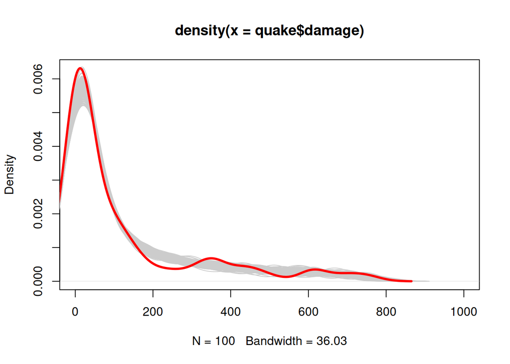

```r
plot(density(quake$damage), type = 'n', xlim = c(0, 1000))
for(i in sample(1:nrow(x_rep), 200)){
    lines(density(x_rep[i,]), col = 'gray80')
}
lines(density(quake$damage), col = 'red', lwd = 3)
```

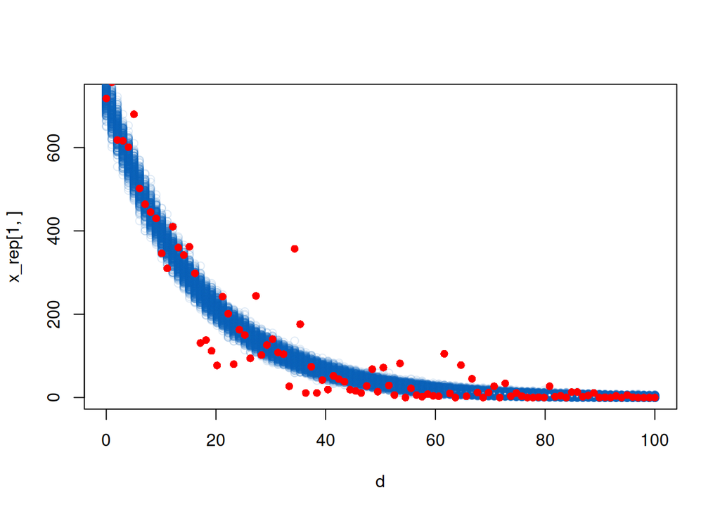

```r
plot(d, x_rep[1,], col = "#0f63bd20" )
for(i in sample(1:nrow(x_rep), 500) ) {
    points(d, x_rep[i,], col = "#0f63bd20")
}
points(d, quake$damage, col =  'red', pch = 16)
```